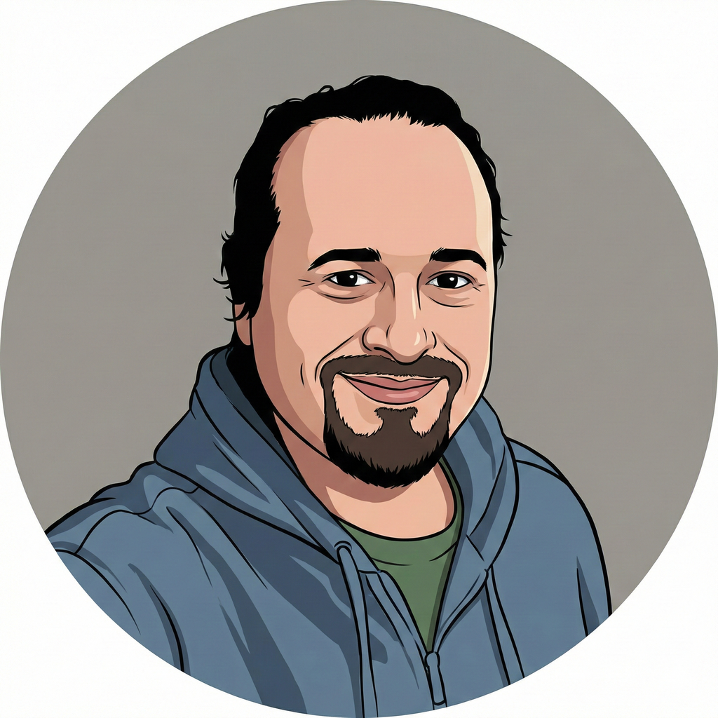

# About me

Hi, I’m James Lindsay (jimbo).

I’m the Director of Software Engineering and a bioinformatics engineer in the Department of Data Science at the [Dana-Farber Cancer Institute](https://www.dana-farber.org/).

My work sits at the intersection of cancer genomics, spatial biology, and clinical informatics. I spend my days building software and data infrastructure that translates massive genomic datasets into something clinicians can actually use to help patients.

Most notably, I helped architect **MatchMiner**, an open-source platform that automatically matches cancer patients to clinical trials based on their genomic profiles. I also led the development of **ImmunoProfile**, a machine-learning workflow that uses spatial data to understand the tumor immune microenvironment.

I’ve also built infrastructure for major national consortia like **AACR Project GENIE** and contribute to the **cBioPortal**.

## About this blog

I wanted to start writing casually for a long time but I’ve always struggled getting started. Through my profesesional career I’ve found academic writing to be exetremely challenging and time consuming and some inital attempts at “blogging” failed quickly. I tried again recently, this time relying heavily on AI tools to help with the writing. If I can successfully keep this going I’ll describe my process. In general the text on this page is mostly written by me but heavily edited by AI.

[Twitter](https://x.com/jim_bo_) [LinkedIn](https://www.linkedin.com/in/jamesrlindsay/) [Github](https://github.com/jim-bo)